# Association with a sea anemone alters the skin microbiome of clownfish

Victoria French, Grace Beery & Madison Pacaro

March 9, 2021

# Introduction

Sea anemone hosting temporarily alters clownfish skin microbiome. After analyzing the microbiome of clownfish not exposed to anemones, clownfish associated with anemones, and clownfish after being removed from their associated anemones, it was found that the microbiome of clownfish mucous is significantly different between hosting and non-hosting individuals. Interestingly, it was also found that a hosting clownfish’s mucosal microbiome returns to that of a non-associated clownfish when removed from the associated anemone for a number of weeks (Pratte et al, 2018). We analyzed a subset of the data presented by Pratte et al, to gain practice with RStudio metabarcoding and to test the replicability of the authors’ genomic analysis. We used the DADA2 pipeline to filter and analyze Illumina raw sequence reads, to assign taxonomic classification via the SILVA v138 reference database, of anemone, clownfish and the associated water column. We utilized phyloseq to visualize this data and construct an ordinate plot based on Bray-Curtis dissimilarity to identify relatedness between sample microbiomes. We found that the microbial community was similar across analyses but lost specificity with the reduction of sample sizes in this replication. The differences found in taxonomic assignment contributed to inconclusive results when analyzing microbiome relatedness. Overall, this project was able to successfully replicate methods of the original analysis but was unable to produce the same results as were found in the original paper.

Pratte ZA, Patin NV, McWhirt ME, Caughman AM, Parris DJ, Stewart FJ (2018) Association with a sea anemone alters the skin microbiome of clownfish. Coral Reefs 37:1119-1125

# Version Control

R version 4.0.3 was used for all analyses.

dada2 package version 1.18.0

ShortRead package version 1.48.0

ggplot2 package version 3.3.3

phyloseq package version 1.34.0

```r
library(dada2); #packageVersion("dada2"); citation("dada2")
library(ShortRead); #packageVersion("ShortRead")
library(ggplot2); #packageVersion("ggplot2")
library(phyloseq); #packageVersion("phyloseq")
```

# Data Analysis & Methods

First we designated a path to the fastq files we will be analyzing.

```r
path <-"C:/Users/Maddy/Documents/BI586/fishmicrobes_2021_assign1/fastqfiles"
fns <- list.files(path)
fns
```

To divide fastq files into matched forward and reversed lists, determined by either a _1 or _2, we first had to ensure fastq files were in the same order. We then removed the .fastq from each file name.

```r
fastqs <- fns[grepl(".fastq$", fns)]
fastqs <- sort(fastqs)
fnFs <- fastqs[grepl("_1", fastqs)]
fnRs <- fastqs[grepl("_2", fastqs)]

sample.names <- sapply(strsplit(basename(fnFs), "_"), `[`, 1)
```

We then set the full path to our forward and reverse reads.

```r
fnFs <- file.path(path, fnFs)
fnRs <- file.path(path, fnRs)
fnFs
fnRs
```

Quality profiles were then plotted for forward and reverse reads to determine where to trim them.

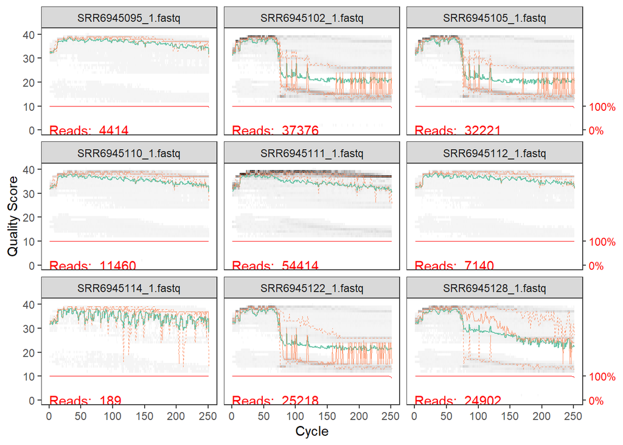

```r
#Forward 1-9
plotQualityProfile(fnFs[1:9])
```

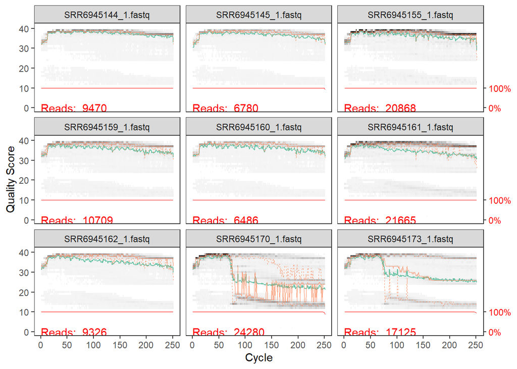

```r
#Forward 10-18
plotQualityProfile(fnFs[10:18])
```

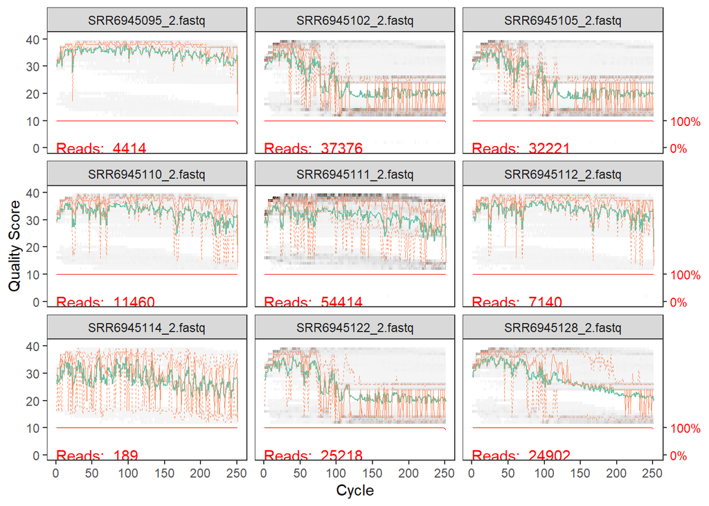

```r
#Reverse 1-9
plotQualityProfile(fnRs[1:9])
```

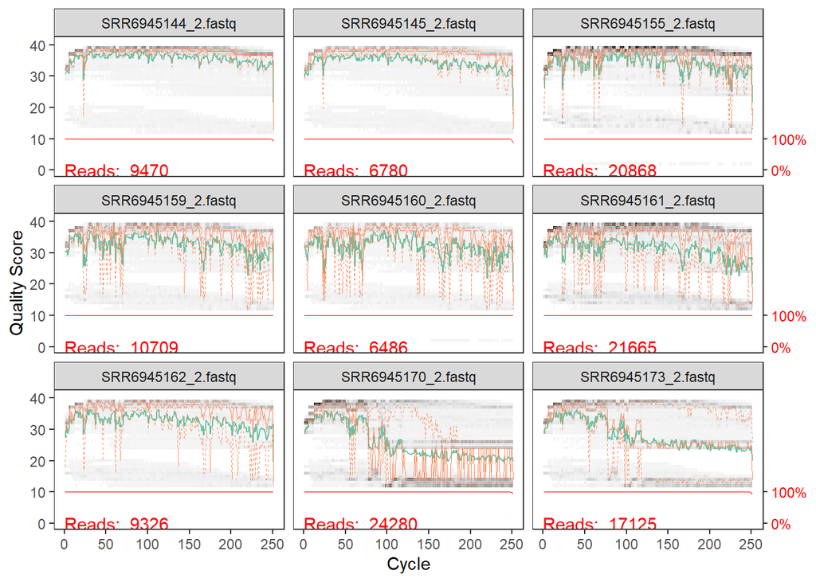

```r
#Reverse 10-18
plotQualityProfile(fnRs[10:18])
```

We then created a new subdirectory for trimmed and filtered files.

```r
filt_path <- file.path(path, "trimmed")
if(!file_test("-d", filt_path)) dir.create(filt_path)
filtFs <- file.path(path, "filtered", paste0(sample.names, "_F_filt.fastq.gz"))
filtRs <- file.path(path, "filtered", paste0(sample.names, "_R_filt.fastq.gz"))
names(filtFs) <- sample.names
names(filtRs) <- sample.names
```

We determined that 240 maximizes the read output during inital filtering and minimizes presence of bimeras while still resulting in successful paired end merges. We excluded the filtering parameter ‘Trimleft’ because our raw data did not contain primer sequences. The primer sequences used were

- 515F (‘GTGYCAGCMGCCGCGGTAA’)
- 806R (‘GGACTACNVGGGTWTCTAAT’)

for the 16S V4 region according to earth microbiome project.

```r
out <- filterAndTrim(fnFs, filtFs, fnRs, filtRs, truncLen=240,
                     maxN=0,
                     maxEE=1,
                     truncQ=2,
                     rm.phix=TRUE,
                     compress=TRUE, multithread=FALSE)
```

```r
head(out)
```

```
##                    reads.in reads.out
## SRR6945095_1.fastq     4414      3108
## SRR6945102_1.fastq    37376      3962
## SRR6945105_1.fastq    32221      3032
## SRR6945110_1.fastq    11460      6351
## SRR6945111_1.fastq    54414     22848
## SRR6945112_1.fastq     7140      4596
```

```r
tail(out)
```

```
##                    reads.in reads.out
## SRR6945159_1.fastq    10709      5595
## SRR6945160_1.fastq     6486      2934
## SRR6945161_1.fastq    21665      9284
## SRR6945162_1.fastq     9326      5587
## SRR6945170_1.fastq    24280      3149
## SRR6945173_1.fastq    17125      5112
```

DADA2 was then utilized to employ a parametric error model to determine the error rate of the amplicon dataset. We kept the standard max consistency of 30 to increase the number of cycles and allow for convergence.

```r
setDadaOpt(MAX_CONSIST=30)
errF <- learnErrors(filtFs, multithread=TRUE)
```

```
## 26232960 total bases in 109304 reads from 18 samples will be used for learning the error rates.
```

```r
errR <- learnErrors(filtRs, multithread=TRUE)
```

```
## 26232960 total bases in 109304 reads from 18 samples will be used for learning the error rates.
```

We plotted the found forward and reverse errors to visually confirm our data. The black line represents the estimated error rates, and the points represent the fit of the error rates. We should see a negative linear relationship in error rates, as quality score increases.

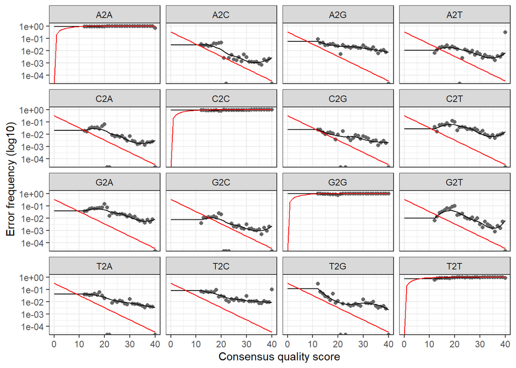

```r
plotErrors(errF, nominalQ=TRUE)
```